# Merge Tipsy Volumes

D. Waddell and G. Nienaber

October 21, 2019

Note that data files are assumed to be located in:  
C:/Data/projects/ResultsDelivery/tsaxx

Make sure that this folder exists and that this is where the data resides.  
Othrwise, correct the folder location in the paramaters

```r
#load libraries
library(tidyverse)
library(kableExtra)

#unpack parameters

  # file location
  inFolder <- str_c(params$data_directory,"/tsa",params$tsa,"/")
  natFileName <- str_c(inFolder,"agg_nat_fid_out_tsa",params$tsa,".csv")
  plantFileName <- str_c(inFolder,"agg_pl_fid_out_tsa",params$tsa,".csv")
  finalFileName <- str_c(inFolder,"weighted_vols_tsa",params$tsa,".csv")

  # deciduous inclusion factor
  inc_decid <- as.numeric(params$decid)

  # planted percent
  pct_plant <- as.numeric(params$planted/100.0)
  pct_nat <- as.numeric(1 - params$planted/100.0)
```

Read in the Natural Regeneration Yields Tables from: C:/Data/projects/ResultsDelivery/tsa43/agg_nat_fid_out_tsa43.csv

```r
r_nat <- read_csv(natFileName) %>%
  select(
    'feature_id' = Identifier,
    'ncvol010' = mvcon.10,
    'ncvol020' = mvcon.20,
    'ncvol030' = mvcon.30,
    'ncvol040' = mvcon.40,
    'ncvol050' = mvcon.50,
    'ncvol060' = mvcon.60,
    'ncvol070' = mvcon.70,
    'ncvol080' = mvcon.80,
    'ncvol090' = mvcon.90,
    'ncvol100' = mvcon.100,
    'ncvol110' = mvcon.110,
    'ncvol120' = mvcon.120,
    'ncvol130' = mvcon.130,
    'ncvol140' = mvcon.140,
    'ncvol150' = mvcon.150,
    'ncvol160' = mvcon.160,
    'ncvol170' = mvcon.170,
    'ncvol180' = mvcon.180,
    'ncvol190' = mvcon.190,
    'ncvol200' = mvcon.200,
    'ncvol210' = mvcon.210,
    'ncvol220' = mvcon.220,
    'ncvol230' = mvcon.230,
    'ncvol240' = mvcon.240,
    'ncvol250' = mvcon.250,
    'ncvol260' = mvcon.260,
    'ncvol270' = mvcon.270,
    'ncvol280' = mvcon.280,
    'ncvol290' = mvcon.290,
    'ncvol300' = mvcon.300,
    'ncvol310' = mvcon.310,
    'ncvol320' = mvcon.320,
    'ncvol330' = mvcon.330,
    'ncvol340' = mvcon.340,
    'ncvol350' = mvcon.350,
    'ndvol010' = mvdec.10,
    'ndvol020' = mvdec.20,
    'ndvol030' = mvdec.30,
    'ndvol040' = mvdec.40,
    'ndvol050' = mvdec.50,
    'ndvol060' = mvdec.60,
    'ndvol070' = mvdec.70,
    'ndvol080' = mvdec.80,
    'ndvol090' = mvdec.90,
    'ndvol100' = mvdec.100,
    'ndvol110' = mvdec.110,
    'ndvol120' = mvdec.120,
    'ndvol130' = mvdec.130,
    'ndvol140' = mvdec.140,
    'ndvol150' = mvdec.150,
    'ndvol160' = mvdec.160,
    'ndvol170' = mvdec.170,
    'ndvol180' = mvdec.180,
    'ndvol190' = mvdec.190,
    'ndvol200' = mvdec.200,
    'ndvol210' = mvdec.210,
    'ndvol220' = mvdec.220,
    'ndvol230' = mvdec.230,
    'ndvol240' = mvdec.240,
    'ndvol250' = mvdec.250,
    'ndvol260' = mvdec.260,
    'ndvol270' = mvdec.270,
    'ndvol280' = mvdec.280,
    'ndvol290' = mvdec.290,
    'ndvol300' = mvdec.300,
    'ndvol310' = mvdec.310,
    'ndvol320' = mvdec.320,
    'ndvol330' = mvdec.330,
    'ndvol340' = mvdec.340,
    'ndvol350' = mvdec.350
  )
```

Read in the Planted Regeneration Yields Tables from: C:/Data/projects/ResultsDelivery/tsa43/agg_pl_fid_out_tsa43.csv

```r
r_plant <- read_csv(plantFileName) %>%
  select(
    'feature_id' = Identifier,
    'pcvol010' = mvcon.10,
    'pcvol020' = mvcon.20,
    'pcvol030' = mvcon.30,
    'pcvol040' = mvcon.40,
    'pcvol050' = mvcon.50,
    'pcvol060' = mvcon.60,
    'pcvol070' = mvcon.70,
    'pcvol080' = mvcon.80,
    'pcvol090' = mvcon.90,
    'pcvol100' = mvcon.100,
    'pcvol110' = mvcon.110,
    'pcvol120' = mvcon.120,
    'pcvol130' = mvcon.130,
    'pcvol140' = mvcon.140,
    'pcvol150' = mvcon.150,
    'pcvol160' = mvcon.160,
    'pcvol170' = mvcon.170,
    'pcvol180' = mvcon.180,
    'pcvol190' = mvcon.190,
    'pcvol200' = mvcon.200,
    'pcvol210' = mvcon.210,
    'pcvol220' = mvcon.220,
    'pcvol230' = mvcon.230,
    'pcvol240' = mvcon.240,
    'pcvol250' = mvcon.250,
    'pcvol260' = mvcon.260,
    'pcvol270' = mvcon.270,
    'pcvol280' = mvcon.280,
    'pcvol290' = mvcon.290,
    'pcvol300' = mvcon.300,
    'pcvol310' = mvcon.310,
    'pcvol320' = mvcon.320,
    'pcvol330' = mvcon.330,
    'pcvol340' = mvcon.340,
    'pcvol350' = mvcon.350,
    'pdvol010' = mvdec.10,
    'pdvol020' = mvdec.20,
    'pdvol030' = mvdec.30,
    'pdvol040' = mvdec.40,
    'pdvol050' = mvdec.50,
    'pdvol060' = mvdec.60,
    'pdvol070' = mvdec.70,
    'pdvol080' = mvdec.80,
    'pdvol090' = mvdec.90,
    'pdvol100' = mvdec.100,
    'pdvol110' = mvdec.110,
    'pdvol120' = mvdec.120,
    'pdvol130' = mvdec.130,
    'pdvol140' = mvdec.140,
    'pdvol150' = mvdec.150,
    'pdvol160' = mvdec.160,
    'pdvol170' = mvdec.170,
    'pdvol180' = mvdec.180,
    'pdvol190' = mvdec.190,
    'pdvol200' = mvdec.200,
    'pdvol210' = mvdec.210,
    'pdvol220' = mvdec.220,
    'pdvol230' = mvdec.230,
    'pdvol240' = mvdec.240,
    'pdvol250' = mvdec.250,
    'pdvol260' = mvdec.260,
    'pdvol270' = mvdec.270,
    'pdvol280' = mvdec.280,
    'pdvol290' = mvdec.290,
    'pdvol300' = mvdec.300,
    'pdvol310' = mvdec.310,
    'pdvol320' = mvdec.320,
    'pdvol330' = mvdec.330,
    'pdvol340' = mvdec.340,
    'pdvol350' = mvdec.350
  )
```

```r
final_vol <-

  #join the tables
  left_join(r_nat, r_plant, by = "feature_id") %>%

  #replace all NULL with 0
  replace(is.na(.), 0) %>%

  #calculate final vol
  mutate(
    vol010 = (ncvol010 + inc_decid * ndvol010) * pct_nat + (pcvol010 + inc_decid * pdvol010) * pct_plant,
    vol020 = (ncvol020 + inc_decid * ndvol020) * pct_nat + (pcvol020 + inc_decid * pdvol020) * pct_plant,
    vol030 = (ncvol030 + inc_decid * ndvol030) * pct_nat + (pcvol030 + inc_decid * pdvol030) * pct_plant,
    vol040 = (ncvol040 + inc_decid * ndvol040) * pct_nat + (pcvol040 + inc_decid * pdvol040) * pct_plant,
    vol050 = (ncvol050 + inc_decid * ndvol050) * pct_nat + (pcvol050 + inc_decid * pdvol050) * pct_plant,
    vol060 = (ncvol060 + inc_decid * ndvol060) * pct_nat + (pcvol060 + inc_decid * pdvol060) * pct_plant,
    vol070 = (ncvol070 + inc_decid * ndvol070) * pct_nat + (pcvol070 + inc_decid * pdvol070) * pct_plant,
    vol080 = (ncvol080 + inc_decid * ndvol080) * pct_nat + (pcvol080 + inc_decid * pdvol080) * pct_plant,
    vol090 = (ncvol090 + inc_decid * ndvol090) * pct_nat + (pcvol090 + inc_decid * pdvol090) * pct_plant,
    vol100 = (ncvol100 + inc_decid * ndvol100) * pct_nat + (pcvol100 + inc_decid * pdvol100) * pct_plant,
    vol110 = (ncvol110 + inc_decid * ndvol110) * pct_nat + (pcvol110 + inc_decid * pdvol110) * pct_plant,
    vol120 = (ncvol120 + inc_decid * ndvol120) * pct_nat + (pcvol120 + inc_decid * pdvol120) * pct_plant,
    vol130 = (ncvol130 + inc_decid * ndvol130) * pct_nat + (pcvol130 + inc_decid * pdvol130) * pct_plant,
    vol140 = (ncvol140 + inc_decid * ndvol140) * pct_nat + (pcvol140 + inc_decid * pdvol140) * pct_plant,
    vol150 = (ncvol150 + inc_decid * ndvol150) * pct_nat + (pcvol150 + inc_decid * pdvol150) * pct_plant,
    vol160 = (ncvol160 + inc_decid * ndvol160) * pct_nat + (pcvol160 + inc_decid * pdvol160) * pct_plant,
    vol170 = (ncvol170 + inc_decid * ndvol170) * pct_nat + (pcvol170 + inc_decid * pdvol170) * pct_plant,
    vol180 = (ncvol180 + inc_decid * ndvol180) * pct_nat + (pcvol180 + inc_decid * pdvol180) * pct_plant,
    vol190 = (ncvol190 + inc_decid * ndvol190) * pct_nat + (pcvol190 + inc_decid * pdvol190) * pct_plant,
    vol200 = (ncvol200 + inc_decid * ndvol200) * pct_nat + (pcvol200 + inc_decid * pdvol200) * pct_plant,
    vol210 = (ncvol210 + inc_decid * ndvol210) * pct_nat + (pcvol210 + inc_decid * pdvol210) * pct_plant,
    vol220 = (ncvol220 + inc_decid * ndvol220) * pct_nat + (pcvol220 + inc_decid * pdvol220) * pct_plant,
    vol230 = (ncvol230 + inc_decid * ndvol230) * pct_nat + (pcvol230 + inc_decid * pdvol230) * pct_plant,
    vol240 = (ncvol240 + inc_decid * ndvol240) * pct_nat + (pcvol240 + inc_decid * pdvol240) * pct_plant,
    vol250 = (ncvol250 + inc_decid * ndvol250) * pct_nat + (pcvol250 + inc_decid * pdvol250) * pct_plant,
    vol260 = (ncvol260 + inc_decid * ndvol260) * pct_nat + (pcvol260 + inc_decid * pdvol260) * pct_plant,
    vol270 = (ncvol270 + inc_decid * ndvol270) * pct_nat + (pcvol270 + inc_decid * pdvol270) * pct_plant,
    vol280 = (ncvol280 + inc_decid * ndvol280) * pct_nat + (pcvol280 + inc_decid * pdvol280) * pct_plant,
    vol290 = (ncvol290 + inc_decid * ndvol290) * pct_nat + (pcvol290 + inc_decid * pdvol290) * pct_plant,
    vol300 = (ncvol300 + inc_decid * ndvol300) * pct_nat + (pcvol300 + inc_decid * pdvol300) * pct_plant,
    vol310 = (ncvol310 + inc_decid * ndvol310) * pct_nat + (pcvol310 + inc_decid * pdvol310) * pct_plant,
    vol320 = (ncvol320 + inc_decid * ndvol320) * pct_nat + (pcvol320 + inc_decid * pdvol320) * pct_plant,
    vol330 = (ncvol330 + inc_decid * ndvol330) * pct_nat + (pcvol330 + inc_decid * pdvol330) * pct_plant,
    vol340 = (ncvol340 + inc_decid * ndvol340) * pct_nat + (pcvol340 + inc_decid * pdvol340) * pct_plant,
    vol350 = (ncvol350 + inc_decid * ndvol350) * pct_nat + (pcvol350 + inc_decid * pdvol350) * pct_plant
  )
```

Here you can run a quality assurance check on the merged volumes. Select feature_id from your data set that contain data for all four curve types.

```r
final_vol %>%
  select(feature_id, ncvol150, ndvol150, pcvol150, pdvol150, vol150) %>%
  filter(feature_id %in% c(5445216,5442685,5456216)) %>%
  knitr::kable() %>% kable_styling(bootstrap_options = c("striped","bordered"), full_width = T)
```

| feature_id | ncvol150 | ndvol150 | pcvol150 | pdvol150 | vol150 |
| --- | --- | --- | --- | --- | --- |
| 5445216 | 316.5 | 0.7 | 346.1 | 0 | 331.30 |
| 5442685 | 520.6 | 2.9 | 554.3 | 0 | 537.45 |
| 5456216 | 418.5 | 0.0 | 460.7 | 0 | 439.60 |

Plot the example curves to review the merging. Again, substitue your own feature_id.

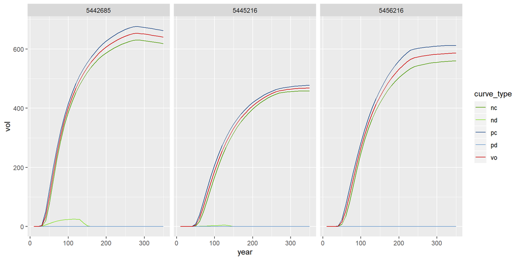

```r
lines <- c("longdash", "dotted", "longdash", "dotted", "solid")
final_vol %>%
  filter(feature_id %in% c(5445216,5442685,5456216)) %>%
  gather(-feature_id, key = 'year', value = 'vol') %>%
  mutate(
    curve_type = str_sub(year,1,2),
    year = as.numeric(str_sub(year, -3))
  ) %>%
  ggplot(aes(year, vol, group=curve_type)) +
    geom_line(aes(color=curve_type)) +
    scale_colour_manual(values = c('#4e9a06', '#8ae234', '#204a87', '#729fcf', '#cc0000')) +
    facet_wrap(~feature_id)
```

The final merged curves are output to: C:/Data/projects/ResultsDelivery/tsa43/weighted_vols_tsa43.csv in CSV format. Optionally, a tab delimited file can be output for use in SELES.

```r
final_vol %>%
  select(
    feature_id,
    vol010,
    vol020,
    vol030,
    vol040,
    vol050,
    vol060,
    vol070,
    vol080,
    vol090,
    vol100,
    vol110,
    vol120,
    vol130,
    vol140,
    vol150,
    vol160,
    vol170,
    vol180,
    vol190,
    vol200,
    vol210,
    vol220,
    vol230,
    vol240,
    vol250,
    vol260,
    vol270,
    vol280,
    vol290,
    vol300,
    vol310,
    vol320,
    vol330,
    vol340,
    vol350
  ) %>%

  #write to comma separated file
  write_csv(finalFileName)

  #write to tab separated file (SELES)
  #write_tsv(finalFileName)
```

Done.